# Reproducible Research Week 4 Project Work

Gudur Guy

6/12/2023

## Synopsis: Impact of Adverse Weather on General Population and Economy

Storms and other severe weather events can cause both public health and economic problems for communities and municipalities. Many severe events can result in fatalities, injuries, and property damage, and preventing such outcomes to the extent possible is a key concern.

This project involves exploring the U.S. National Oceanic and Atmospheric Administration’s (NOAA) storm database. This database tracks characteristics of major storms and weather events in the United States, including when and where they occur, as well as estimates of any fatalities, injuries, and property damage.

In this present report, we will look at the impact of severe weather on the personnel and the property & crop damages caused by these. We will look at what adverse weather events cause most harm to people and also what events has the damaging effect on the properties and crops there by impacting the economy at large.

## 1. Data

The data for this assignment come in the form of a comma-separated-value file compressed via the bzip2 algorithm to reduce its size. You can download the file from the course web site:

[Storm Data](https://d396qusza40orc.cloudfront.net/repdata%2Fdata%2FStormData.csv.bz2)

There is also some documentation of the database available. Here you will find how some of the variables are constructed/defined.

National Weather Service [Storm Data Documentation](https://d396qusza40orc.cloudfront.net/repdata%2Fpeer2_doc%2Fpd01016005curr.pdf)

National Climatic Data Center Storm Events [FAQ](https://d396qusza40orc.cloudfront.net/repdata%2Fpeer2_doc%2FNCDC%20Storm%20Events-FAQ%20Page.pdf)

The events in the database start in the year 1950 and end in November 2011. In the earlier years of the database there are generally fewer events recorded, most likely due to a lack of good records. More recent years should be considered more complete.

## 2. Data Processing

### 2.1 Load Required Libraries

```r
#load the required libraries
knitr::opts_chunk$set(echo = TRUE)
library(knitr)
opts_chunk$set(echo=TRUE,  warning=FALSE)
library(dplyr)
```

```r
options(dplyr.summarise.inform = FALSE)
library(ggplot2)
```

### 2.2 Data Loading

The data is downloaded from the web site mentioned above and then loaded into R as shown below.

```r
# files and url variables
destFilename <- "repdata_data_StormData.csv.bz2"
URL <- "(https://d396qusza40orc.cloudfront.net/repdata%2Fdata%2FStormData.csv.bz2"
# if the zip file does not exists, then download
if (!file.exists(destFilename)){
  download.file(URL, destFilename, method="curl")
}
#read bz2 file
stormDataF <- read.csv(destFilename)
```

### 2.3 Check Data

Please check the data to see various dattails and elements of the data such as dimensions, columns names, start and end date of the observations .

```r
dim(stormDataF)
```

```
## [1] 902297     37
```

```r
colnames(stormDataF)
```

```
##  [1] "STATE__"    "BGN_DATE"   "BGN_TIME"   "TIME_ZONE"  "COUNTY"
##  [6] "COUNTYNAME" "STATE"      "EVTYPE"     "BGN_RANGE"  "BGN_AZI"
## [11] "BGN_LOCATI" "END_DATE"   "END_TIME"   "COUNTY_END" "COUNTYENDN"
## [16] "END_RANGE"  "END_AZI"    "END_LOCATI" "LENGTH"     "WIDTH"
## [21] "F"          "MAG"        "FATALITIES" "INJURIES"   "PROPDMG"
## [26] "PROPDMGEXP" "CROPDMG"    "CROPDMGEXP" "WFO"        "STATEOFFIC"
## [31] "ZONENAMES"  "LATITUDE"   "LONGITUDE"  "LATITUDE_E" "LONGITUDE_"
## [36] "REMARKS"    "REFNUM"
```

```r
head(stormDataF$BGN_DATE, 1)
```

```
## [1] "4/18/1950 0:00:00"
```

```r
tail(stormDataF$BGN_DATE, 1)
```

```
## [1] "11/28/2011 0:00:00"
```

### 2.4 Data Extraction and Cleansing as per the needs of the Analysis

```r
colsNeeded <- c("EVTYPE", "FATALITIES", "INJURIES", "PROPDMG", "PROPDMGEXP", "CROPDMG", "CROPDMGEXP")
stormData <- stormDataF[colsNeeded]
dim(stormData)
```

```
## [1] 902297      7
```

```r
#now keep just those rows where there is any kind of damage whether personal or property or crops
stormData <- subset(stormData, (INJURIES > 0 | FATALITIES > 0 | PROPDMG > 0 | CROPDMG > 0) )
#check data
dim(stormData)
```

```
## [1] 254633      7
```

### 2.5 Data Formatting for Numerical Values

The property & crop damage numbers are given in exponential notation.

```r
unique(stormData$PROPDMGEXP)
```

```
##  [1] "K" "M" ""  "B" "m" "+" "0" "5" "6" "4" "h" "2" "7" "3" "H" "-"
```

```r
unique(stormData$CROPDMGEXP)
```

```
## [1] ""  "M" "K" "m" "B" "?" "0" "k"
```

```r
## for property damages, modify the chars as needed
stormData$PROPDMGEXP <- recode(stormData$PROPDMGEXP, .default = 1, "K"=1000, "M"=1000000, "B"=1000000000, "m"=1000000, "+"=1, "-"=1, "0"=1, "2"=100, "3"=1000, "4"=10000, "5"=100000, "6"=1000000, "7"=10000000, "h"=100, "H"=100)
## verify
unique(stormData$PROPDMGEXP)
```

```
## [1] 1e+03 1e+06 1e+00 1e+09 1e+05 1e+04 1e+02 1e+07
```

```r
## for crop damages, modify the chars as needed
stormData$CROPDMGEXP <- recode(stormData$CROPDMGEXP, .default = 1, "0"=1, "?"=1, "K"=1000, "k"=1000, "M"=1000000, "m"=1000000, "B"=1000000000)
## verify
unique(stormData$CROPDMGEXP)
```

```
## [1] 1e+00 1e+06 1e+03 1e+09
```

### 2.6 Calculate Total Property and Crop Damanges

#### 2.6.1 Calculate Total Property Damage

```r
#convert to numeric
stormData$PROPDMGEXP <- as.numeric(stormData$PROPDMGEXP)
# for property damages, calculate and save it in a new column
stormData$PROPDMGEXPTOTALVAL <- NA
#calculate propery damage total
stormData$PROPDMGEXPTOTALVAL <- stormData$PROPDMG * stormData$PROPDMGEXP
```

#### 2.6.1 Calculate Total Crop Damage

```r
#convert to numeric
stormData$CROPDMGEXP <- as.numeric(stormData$CROPDMGEXP)
# for crop damages, calculate and save it in a new column
stormData$CROPDMGEXPTOTALVAL <- NA
#calculate crop damage total
stormData$CROPDMGEXPTOTALVAL <- stormData$CROPDMG * stormData$CROPDMGEXP
```

### 2.7 Calculating the totals for each event by event type

We know that Property Damage and Crop Damages are the most harmful to the econommy So, let us add those two and get total damage by them.

```r
stormData$DMGTOTAL <- stormData$PROPDMGEXPTOTALVAL + stormData$CROPDMGEXPTOTALVAL
head(stormData)
```

```
##    EVTYPE FATALITIES INJURIES PROPDMG PROPDMGEXP CROPDMG CROPDMGEXP
## 1 TORNADO          0       15    25.0       1000       0          1
## 2 TORNADO          0        0     2.5       1000       0          1
## 3 TORNADO          0        2    25.0       1000       0          1
## 4 TORNADO          0        2     2.5       1000       0          1
## 5 TORNADO          0        2     2.5       1000       0          1
## 6 TORNADO          0        6     2.5       1000       0          1
##   PROPDMGEXPTOTALVAL CROPDMGEXPTOTALVAL DMGTOTAL
## 1              25000                  0    25000
## 2               2500                  0     2500
## 3              25000                  0    25000
## 4               2500                  0     2500
## 5               2500                  0     2500
## 6               2500                  0     2500
```

We know that Fatalities and Injuries are the most harmful to the population at large. So, we will add those two and get totals for those two events only

```r
stormData$HARMTOTAL <- stormData$INJURIES + stormData$FATALITIES
head(stormData)
```

```
##    EVTYPE FATALITIES INJURIES PROPDMG PROPDMGEXP CROPDMG CROPDMGEXP
## 1 TORNADO          0       15    25.0       1000       0          1
## 2 TORNADO          0        0     2.5       1000       0          1
## 3 TORNADO          0        2    25.0       1000       0          1
## 4 TORNADO          0        2     2.5       1000       0          1
## 5 TORNADO          0        2     2.5       1000       0          1
## 6 TORNADO          0        6     2.5       1000       0          1
##   PROPDMGEXPTOTALVAL CROPDMGEXPTOTALVAL DMGTOTAL HARMTOTAL
## 1              25000                  0    25000        15
## 2               2500                  0     2500         0
## 3              25000                  0    25000         2
## 4               2500                  0     2500         2
## 5               2500                  0     2500         2
## 6               2500                  0     2500         6
```

### 2.8 Plot Events with Highest harmful incidents

```r
# Aggregate total harmful incidents by event type
totalHarmfuls <- aggregate(HARMTOTAL ~ EVTYPE, stormData, FUN = sum)
# Calculate top 10 events with highest harmful incidents
totalHarmfuls10 <- head(totalHarmfuls[order(totalHarmfuls$HARMTOTAL,decreasing=TRUE),], n = 10)
# show final results
head(totalHarmfuls10)
```

```
##             EVTYPE HARMTOTAL
## 407        TORNADO     96979
## 61  EXCESSIVE HEAT      8428
## 423      TSTM WIND      7461
## 86           FLOOD      7259
## 258      LIGHTNING      6046
## 151           HEAT      3037
```

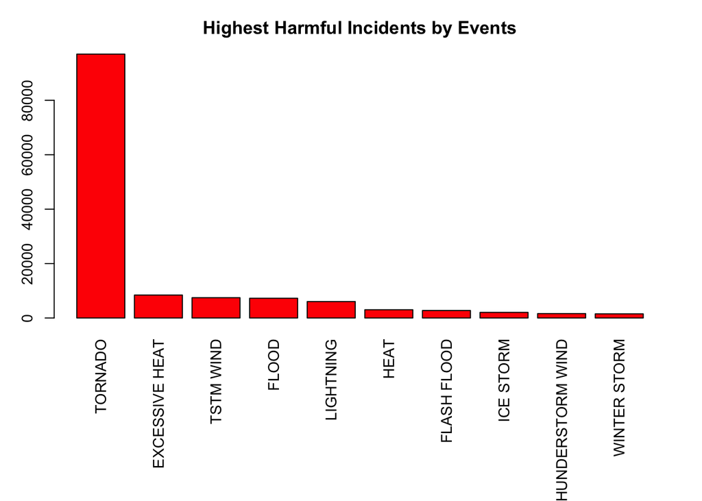

```r
#plot the results
par(mfrow = c(1, 1), mar = c(10, 3, 3, 2),  cex = 0.9)
barplot(totalHarmfuls10$HARMTOTAL, las = 3, names.arg = totalHarmfuls10$EVTYPE, main = "Highest Harmful Incidents by Events",  ylab = "Number of Harmful Incidents", col = "red")
```

### 2.9 Plot Events with Highest Dmages

```r
# Aggregate total damages by event type
totalDamages <- aggregate(DMGTOTAL ~ EVTYPE, stormData, FUN = sum)
# Calculate top 10 events with highest damages
totalDamages10 <- head(totalDamages[order(totalDamages$DMGTOTAL,decreasing=TRUE),], n = 10)
# show final results
head(totalDamages10)
```

```
##                EVTYPE     DMGTOTAL
## 86              FLOOD 150319678257
## 224 HURRICANE/TYPHOON  71913712800
## 407           TORNADO  57362333946
## 350       STORM SURGE  43323541000
## 134              HAIL  18761221986
## 73        FLASH FLOOD  18243991078
```

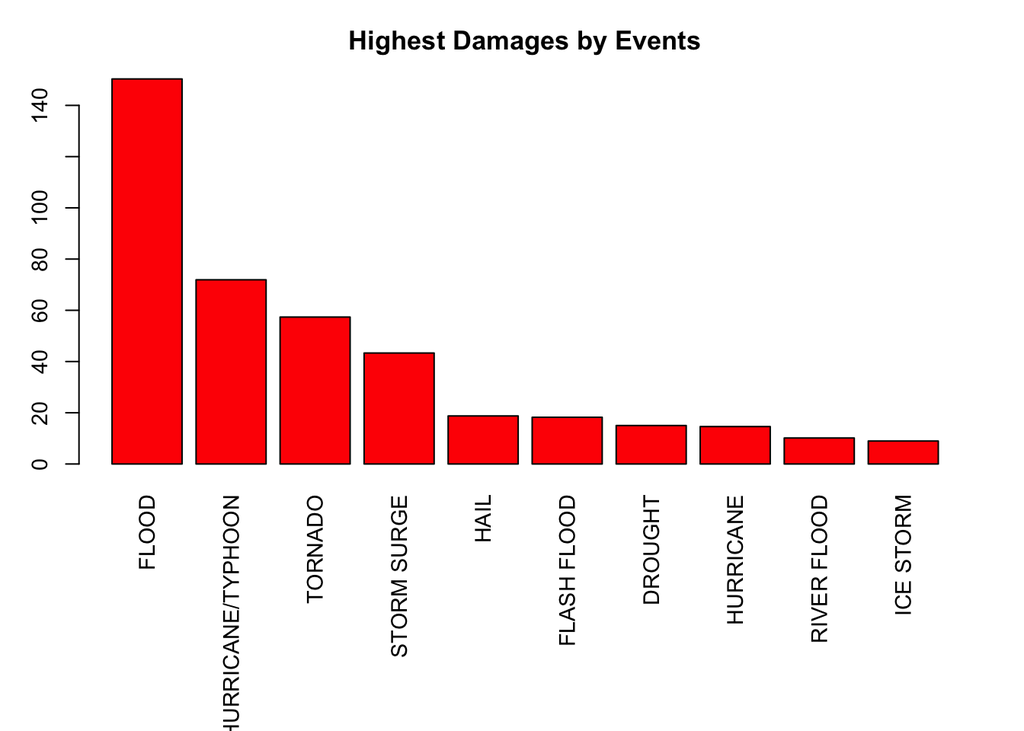

```r
#plot the results
par(mfrow = c(1, 1), mar = c(10, 3, 3, 2),  cex = 0.9)
barplot(totalDamages10$DMGTOTAL/(10^9), las = 3, names.arg = totalDamages10$EVTYPE, main = "Highest Damages by Events",  ylab = "Damage Cost in Billions", col = "red")
```

## 3. Results

After this analysis, we can comfortably answer the following two questions that were posed initially.

1. **Across the United States, which types of events (as indicated in the EVTYPE variable) are most harmful with respect to population health?**
- **The most harmful event is Tornado, followed by Excessive Heat**
2. **Across the United States, which types of events have the greatest economic consequences?**
- **The event that causes most harmful economic impact is Flood, followed by Hurricane/Typhoon**